# Séance 3 - *correction*

## Données `Wine`

```python
import pandas
import numpy
import matplotlib.pyplot as plt
import seaborn
seaborn.set_style("white")

from sklearn.decomposition import PCA
from sklearn.preprocessing import scale
```

```python
url = "https://archive.ics.uci.edu/ml/machine-learning-databases/wine/wine.data"
wine = pandas.read_csv(url, header = None, sep = ",")
wine.columns = ["class", "Alcohol", "Malic acid", "Ash", "Alcalinity of ash", "Magnesium",
                "Total phenols", "Flavanoids", "Nonflavanoid phenols", "Proanthocyanins",
                "Color intensity", "Hue", "OD280/OD315 of diluted wines", "Proline"]
wine
```

|  | class | Alcohol | Malic acid | Ash | Alcalinity of ash | Magnesium | Total phenols | Flavanoids | Nonflavanoid phenols | Proanthocyanins | Color intensity | Hue | OD280/OD315 of diluted wines | Proline |
| --- | --- | --- | --- | --- | --- | --- | --- | --- | --- | --- | --- | --- | --- | --- |
| 0 | 1 | 14.23 | 1.71 | 2.43 | 15.6 | 127 | 2.80 | 3.06 | 0.28 | 2.29 | 5.64 | 1.04 | 3.92 | 1065 |
| 1 | 1 | 13.20 | 1.78 | 2.14 | 11.2 | 100 | 2.65 | 2.76 | 0.26 | 1.28 | 4.38 | 1.05 | 3.40 | 1050 |
| 2 | 1 | 13.16 | 2.36 | 2.67 | 18.6 | 101 | 2.80 | 3.24 | 0.30 | 2.81 | 5.68 | 1.03 | 3.17 | 1185 |
| 3 | 1 | 14.37 | 1.95 | 2.50 | 16.8 | 113 | 3.85 | 3.49 | 0.24 | 2.18 | 7.80 | 0.86 | 3.45 | 1480 |
| 4 | 1 | 13.24 | 2.59 | 2.87 | 21.0 | 118 | 2.80 | 2.69 | 0.39 | 1.82 | 4.32 | 1.04 | 2.93 | 735 |
| ... | ... | ... | ... | ... | ... | ... | ... | ... | ... | ... | ... | ... | ... | ... |
| 173 | 3 | 13.71 | 5.65 | 2.45 | 20.5 | 95 | 1.68 | 0.61 | 0.52 | 1.06 | 7.70 | 0.64 | 1.74 | 740 |
| 174 | 3 | 13.40 | 3.91 | 2.48 | 23.0 | 102 | 1.80 | 0.75 | 0.43 | 1.41 | 7.30 | 0.70 | 1.56 | 750 |
| 175 | 3 | 13.27 | 4.28 | 2.26 | 20.0 | 120 | 1.59 | 0.69 | 0.43 | 1.35 | 10.20 | 0.59 | 1.56 | 835 |
| 176 | 3 | 13.17 | 2.59 | 2.37 | 20.0 | 120 | 1.65 | 0.68 | 0.53 | 1.46 | 9.30 | 0.60 | 1.62 | 840 |
| 177 | 3 | 14.13 | 4.10 | 2.74 | 24.5 | 96 | 2.05 | 0.76 | 0.56 | 1.35 | 9.20 | 0.61 | 1.60 | 560 |

178 rows × 14 columns

## Décrire les données

- 3 classes globalement équilibrées entre elles

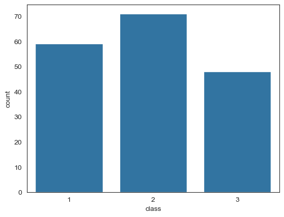

```python
seaborn.countplot(x = "class", data = wine)
plt.show()
```

13 variables quantitatives avec des échelles différentes

- Quelques valeurs aberrantes
- Pas de distribution trop asymétrique

Donc usage de la fonction `scale()` à prévoir

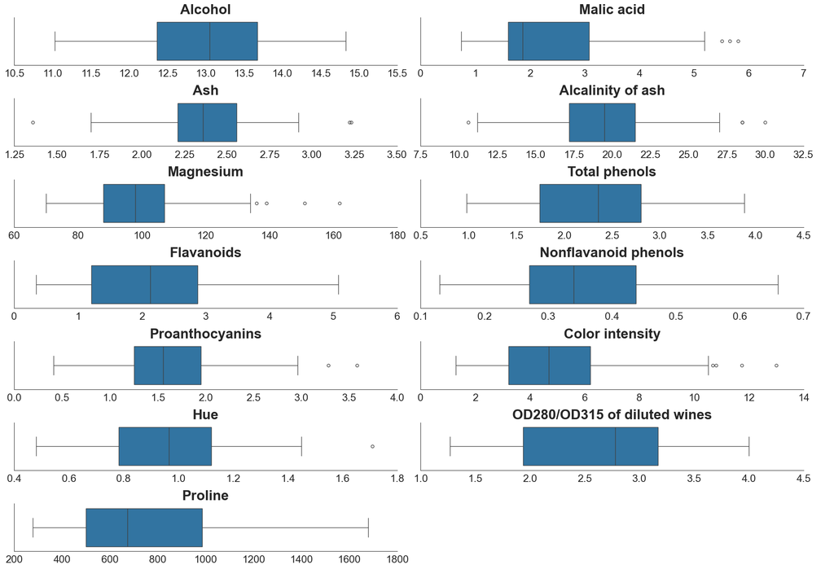

```python
g = seaborn.catplot(x = "value", data = wine.melt(id_vars="class"),
                kind = "box", height = 2, aspect = 5,
                col = "variable", col_wrap = 2, sharex = False)
g.set_titles(col_template = "{col_name}", fontweight = "bold", size = 24)
g.set_xticklabels(size = 18)
g.tight_layout()
g.set_axis_labels(x_var = "")
plt.show()
```

Quelques variables semblent corrélées entre elles :

- *Total phenols* et *Flavanoids* (positivement)
- *Hue* et *Malic acid* (négativement)

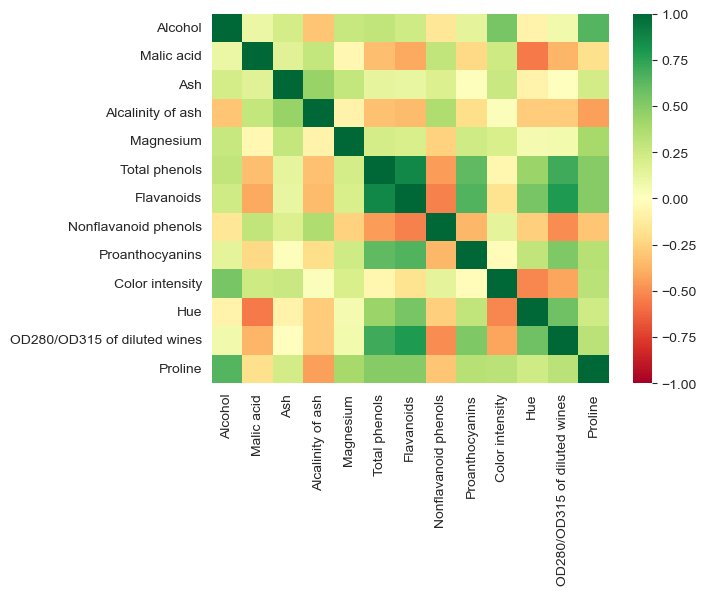

```python
df_cor = wine.drop(columns="class").corr()
seaborn.heatmap(df_cor, vmin = -1, vmax = 1, cmap = "RdYlGn")
plt.show()
```

Voici comment récupérer les corrélations supérieures à .5 ou inférieures à -.5, en supprimant les doublons

```python
df_cor.reset_index().melt(id_vars = "index").query("value < 1").query("abs(value) > .5").sort_values("value", ascending = False)[::2]
```

|  | index | variable | value |
| --- | --- | --- | --- |
| 71 | Flavanoids | Total phenols | 0.864564 |
| 89 | OD280/OD315 of diluted wines | Flavanoids | 0.787194 |
| 148 | Total phenols | OD280/OD315 of diluted wines | 0.699949 |
| 86 | Proanthocyanins | Flavanoids | 0.652692 |
| 156 | Alcohol | Proline | 0.643720 |
| 73 | Proanthocyanins | Total phenols | 0.612413 |
| 153 | Hue | OD280/OD315 of diluted wines | 0.565468 |
| 9 | Color intensity | Alcohol | 0.546364 |
| 136 | Flavanoids | Hue | 0.543479 |
| 115 | OD280/OD315 of diluted wines | Proanthocyanins | 0.519067 |
| 150 | Nonflavanoid phenols | OD280/OD315 of diluted wines | -0.503270 |
| 139 | Color intensity | Hue | -0.521813 |
| 85 | Nonflavanoid phenols | Flavanoids | -0.537900 |
| 23 | Hue | Malic acid | -0.561296 |

## Réaliser une ACP

Ici, variables avec des échelles très différentes $\rightarrow$ ACP normée

```python
wine_bis = scale(wine.drop(columns = "class"))
pca = PCA(n_components = 13)
pca.fit(wine_bis)
```

```
PCA(n_components=13)
```

### Choix du nombre d'axes

- 2 axes permettent d'expliquer 55 % de l'information
- Seuls 3 axes ont une valeur propre plus grande que 1.

```python
eig = pandas.DataFrame(
    {
        "Dimension" : ["Dim" + str(x + 1) for x in range(13)],
        "Valeur propre" : pca.explained_variance_,
        "% variance expliquée" : numpy.round(pca.explained_variance_ratio_ * 100),
        "% cum. var. expliquée" : numpy.round(numpy.cumsum(pca.explained_variance_ratio_) * 100)
    },
    columns = ["Dimension", "Valeur propre", "% variance expliquée", "% cum. var. expliquée"]
)
eig
```

|  | Dimension | Valeur propre | % variance expliquée | % cum. var. expliquée |
| --- | --- | --- | --- | --- |
| 0 | Dim1 | 4.732437 | 36.0 | 36.0 |
| 1 | Dim2 | 2.511081 | 19.0 | 55.0 |
| 2 | Dim3 | 1.454242 | 11.0 | 67.0 |
| 3 | Dim4 | 0.924166 | 7.0 | 74.0 |
| 4 | Dim5 | 0.858049 | 7.0 | 80.0 |
| 5 | Dim6 | 0.645282 | 5.0 | 85.0 |
| 6 | Dim7 | 0.554141 | 4.0 | 89.0 |
| 7 | Dim8 | 0.350466 | 3.0 | 92.0 |
| 8 | Dim9 | 0.290512 | 2.0 | 94.0 |
| 9 | Dim10 | 0.252320 | 2.0 | 96.0 |
| 10 | Dim11 | 0.227064 | 2.0 | 98.0 |
| 11 | Dim12 | 0.169724 | 1.0 | 99.0 |
| 12 | Dim13 | 0.103962 | 1.0 | 100.0 |

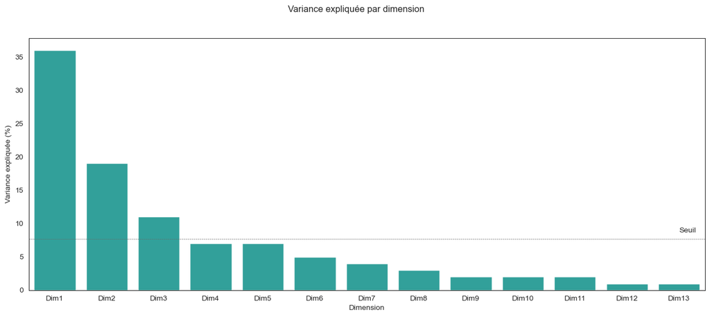

```python
plt.figure(figsize=(16, 6))
g_eig = seaborn.barplot(x = "Dimension",
                        y = "% variance expliquée",
                        color = "lightseagreen",
                        data = eig)
plt.text(12, 100/13 + 1, "Seuil")
plt.axhline(y = 100/13, linewidth = .5, color = "dimgray", linestyle = "--")
g_eig.set(ylabel = "Variance expliquée (%)")
g_eig.figure.suptitle("Variance expliquée par dimension")

plt.show()
```

### Création des graphiques

#### Nuage de points sur le premier plan factoriel

- Les points semblent faire un arc de cercle
- Classes de vin assez séparées

```python
wine_pca_df = pandas.DataFrame(pca.transform(wine_bis),
                               columns = ["Dim" + str(i+1) for i in range(13)]) \
                    .assign(Class = wine["class"])
```

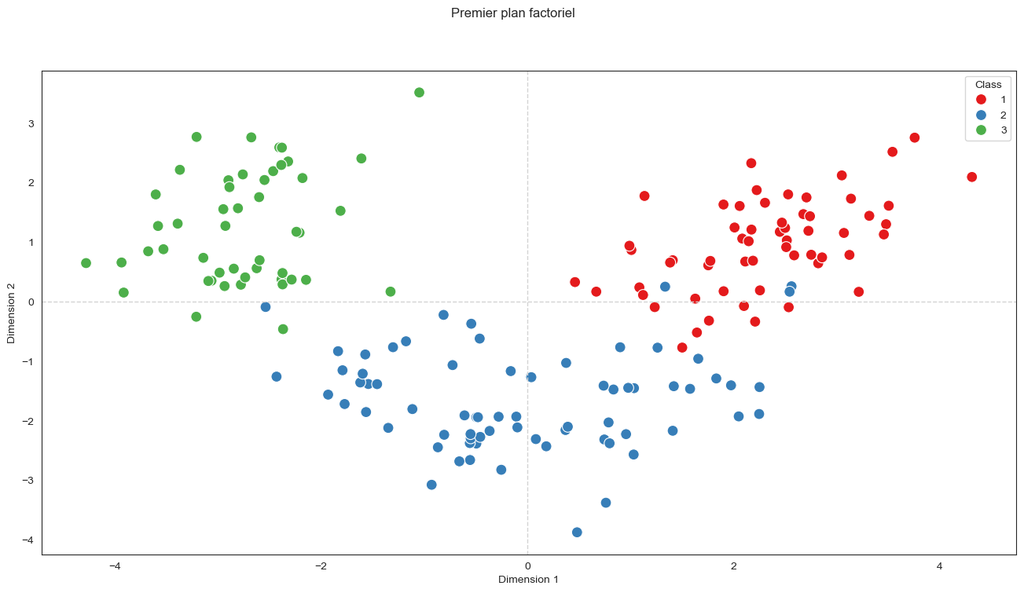

```python
fig, axes = plt.subplots(figsize = (16, 8))
fig.suptitle("Premier plan factoriel")
axes.axvline(x = 0, color = 'lightgray', linestyle = '--', linewidth = 1)
axes.axhline(y = 0, color = 'lightgray', linestyle = '--', linewidth = 1)

g_pca = seaborn.scatterplot(x = "Dim1", y = "Dim2", hue = "Class", data = wine_pca_df,
                            palette = "Set1", s = 100)
g_pca.set(xlabel = "Dimension 1", ylabel = "Dimension 2")

plt.show()
```

#### Cercle de corrélations

```python
coordvar = pca.components_.T * numpy.sqrt(pca.explained_variance_)
coordvar_df = pandas.DataFrame(coordvar, columns=['PC'+str(i+1) for i in range(13)], index=wine.columns[1:])
```

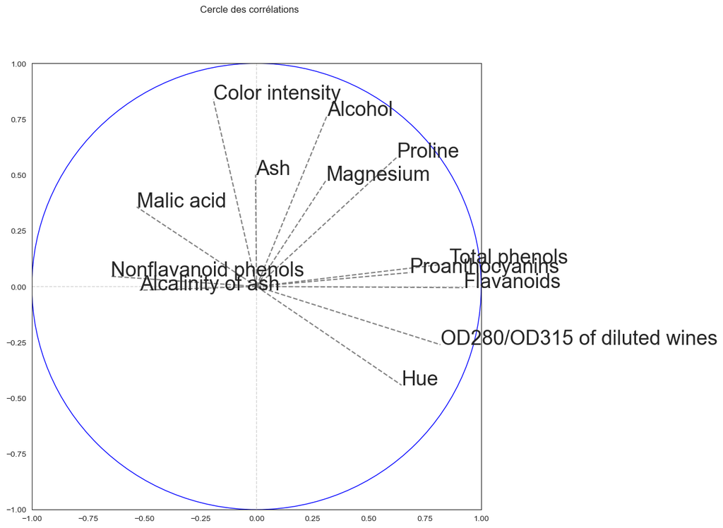

```python
fig, axes = plt.subplots(figsize = (10, 10))
fig.suptitle("Cercle des corrélations")
axes.set_xlim(-1, 1)
axes.set_ylim(-1, 1)
axes.axvline(x = 0, color = 'lightgray', linestyle = '--', linewidth = 1)
axes.axhline(y = 0, color = 'lightgray', linestyle = '--', linewidth = 1)
for j in range(13):
    axes.text(coordvar_df["PC1"].iloc[j],
              coordvar_df["PC2"].iloc[j],
              coordvar_df.index[j], size = 25)
    axes.plot([0,coordvar_df["PC1"].iloc[j]],
              [0,coordvar_df["PC2"].iloc[j]],
              color = "gray", linestyle = 'dashed')
plt.gca().add_artist(plt.Circle((0,0),1,color='blue',fill=False))

plt.show()
```

#### Et si on voulait regarder plus loin, sur les axes 3, 4 et 5 aussi

Il nous faut alors créer tous les couples de graphiques (1, 2), (1, 3), ..., (2,3), (2,4)... Dans le code suivant, il faudra juste changer la valeur dans la variable `nb_composantes` pour avoir plus ou moins de composantes affichées.

Le troisième axe ne semble pas amener d'information sur la séparation des classes. Il est très lié à `Ash` et `Alcanility of ash`. On remarque un point avec une valeur élevée et un point avec une faible valeur. Ce sont sûrement les mêmes qui apparaissent comme outlier sur les boîtes à moustaches de ces deux variables.

##### Pour les variables

```python
def cercle(ax, d1, d2):
    ax.set_xlim(-1, 1)
    ax.set_ylim(-1, 1)
    ax.axvline(x = 0, color = 'lightgray', linestyle = '--', linewidth = 1)
    ax.axhline(y = 0, color = 'lightgray', linestyle = '--', linewidth = 1)
    for j in range(len(d1)):
        ax.text(d1.iloc[j], d2.iloc[j], d1.index[j])
        ax.plot([0, d1.iloc[j]], [0, d2.iloc[j]], color = "gray", linestyle = 'dashed')
```

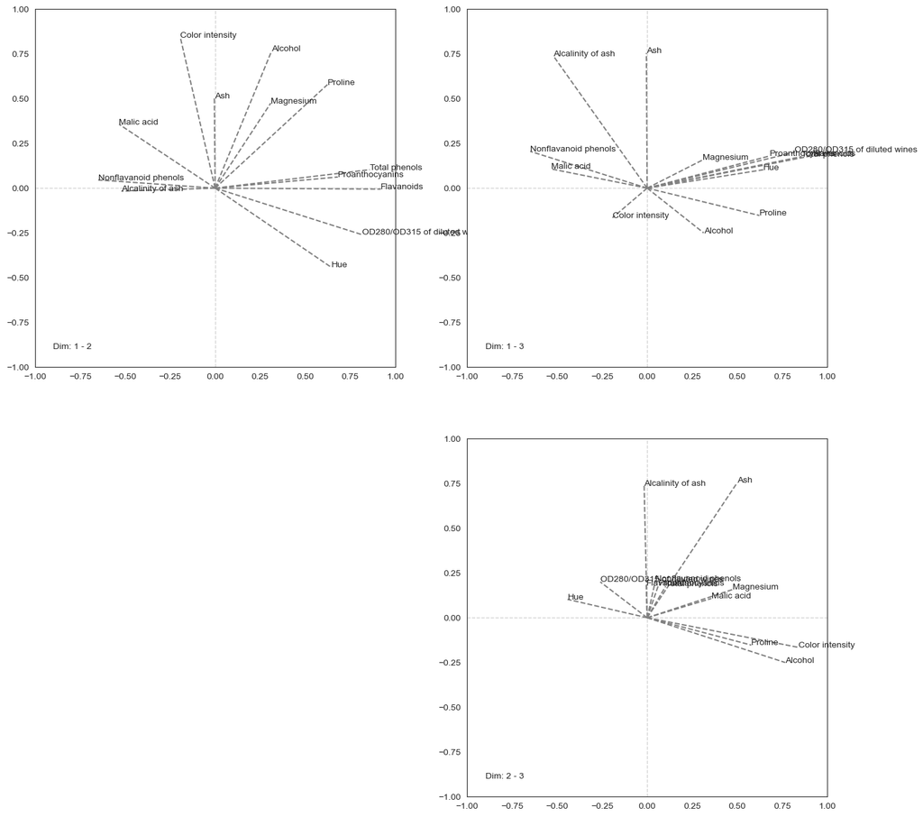

```python
plt.figure(figsize = (16, 16))

nb_composantes = 3

for i in range(1, nb_composantes):
    for j in range(i + 1, nb_composantes + 1):
        ax = plt.subplot2grid((nb_composantes - 1, nb_composantes - 1), (i - 1, j - 2))
        cercle(ax, coordvar_df["PC" + str(i)], coordvar_df["PC" + str(j)])
        ax.text(-.9, -.9, "Dim: " + str(i) + " - " + str(j))
```

##### Pour les individus

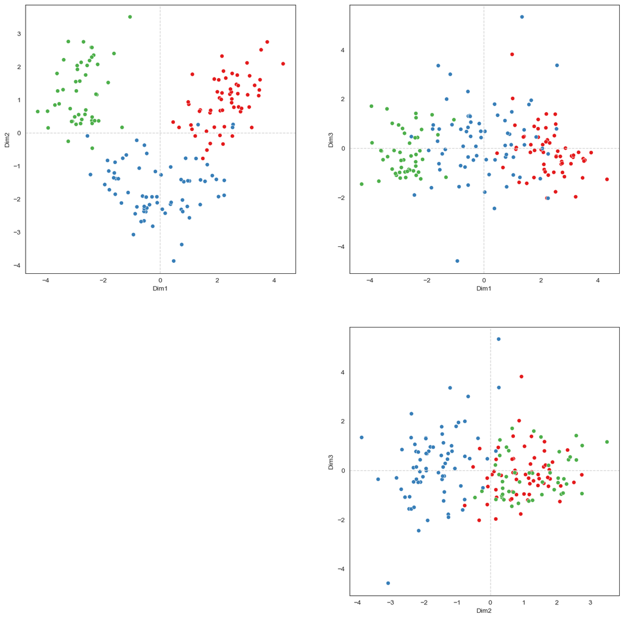

```python
plt.figure(figsize = (16, 16))

for i in range(1, nb_composantes):
    for j in range(i + 1, nb_composantes + 1):
        ax = plt.subplot2grid((nb_composantes - 1, nb_composantes - 1), (i - 1, j - 2))
        ax.axvline(x = 0, color = 'lightgray', linestyle = '--', linewidth = 1)
        ax.axhline(y = 0, color = 'lightgray', linestyle = '--', linewidth = 1)
        seaborn.scatterplot(x = "Dim" + str(i), y = "Dim" + str(j), hue = "Class", data = wine_pca_df, palette = "Set1", legend = False)
```

Comme nous pouvons le voir ci-dessous, la variable `Ash` a trois *outliers* :

- Un avec une valeur très faible (1.36)
- Deux avec une valeur très élevée (3.23 et 3.22)

```python
wine["Ash"].sort_values().head()
```

```
59     1.36
66     1.70
100    1.70
76     1.71
69     1.75
Name: Ash, dtype: float64
```

```python
wine["Ash"].sort_values(ascending = False).head()
```

```
121    3.23
25     3.22
112    2.92
4      2.87
169    2.86
Name: Ash, dtype: float64
```

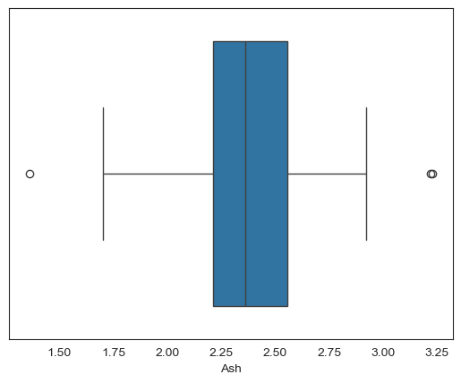

```python
seaborn.boxplot(data = wine, x = "Ash")
```

```python
wine["Alcalinity of ash"].sort_values().head()
```

```
59    10.6
1     11.2
13    11.4
14    12.0
50    12.4
Name: Alcalinity of ash, dtype: float64
```

```python
wine["Alcalinity of ash"].sort_values(ascending = False).head()
```

```
73     30.0
121    28.5
127    28.5
157    27.0
122    26.5
Name: Alcalinity of ash, dtype: float64
```

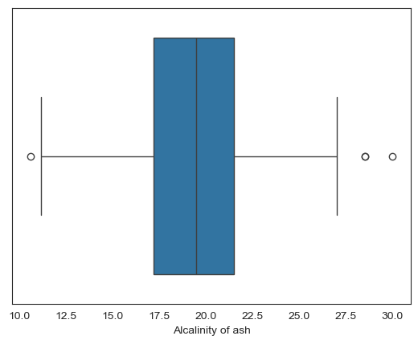

```python
seaborn.boxplot(data = wine, x = "Alcalinity of ash")
```